# Mucosal microbiota alterations in primary sclerosis cholangitis persist after liver transplantation and are associated with clinical features independently of geography

ML models - overfitting check

# 1 Introduction

To prevent potential training errors and overfitting, a validity check was performed for all models by randomly shuffling the sample labels. The performance of these models should not reach significantly high values.

*Importing libraries and custom functions built for this analysis*

```r
source("custom_functions.R")
```

# 2 Data Import

Importing ASV, taxa and metadata tables for both Czech and Norway samples.

**Czech**

```r
path = "../../data/analysis_ready_data/ikem/"
asv_tab_ikem <- as.data.frame(fread(file.path(path,"asv_table_ikem.csv"),
                                    check.names = FALSE))
taxa_tab_ikem <- as.data.frame(fread(file.path(path,"taxa_table_ikem.csv"),
                                     check.names = FALSE))
metadata_ikem <- as.data.frame(fread(file.path(path,"metadata_ikem.csv"),
                                     check.names = FALSE))
```

**Norway**

```r
path = "../../data/analysis_ready_data/norway/"
asv_tab_norway <- as.data.frame(fread(file.path(path,"asv_table_norway.csv"),
                                    check.names = FALSE))
taxa_tab_norway <- as.data.frame(fread(file.path(path,"taxa_table_norway.csv"),
                                    check.names = FALSE))
metadata_norway <- as.data.frame(fread(file.path(path,"metadata_norway.csv"),
                                    check.names = FALSE))
```

# 3 Merging

**Terminal ileum**

```r
ileum_data <- merging_data(asv_tab_1=asv_tab_ikem,
                           asv_tab_2=asv_tab_norway,
                           taxa_tab_1=taxa_tab_ikem,
                           taxa_tab_2=taxa_tab_norway,
                           metadata_1=metadata_ikem,
                           metadata_2=metadata_norway,
                           segment="TI",Q="Q1")
```

```
Removing 1498 ASV(s)
```

```
Removing 1834 ASV(s)
```

```
Merging at ASV level
```

```
Finding inconsistencies in taxonomy, trying to keep the ones that have better taxonomy assignment
```

```r
ileum_asv_tab <- ileum_data[[1]]
ileum_taxa_tab <- ileum_data[[2]]
ileum_metadata <- ileum_data[[3]]
```

**Colon**

```r
colon_data <- merging_data(asv_tab_1=asv_tab_ikem,
                           asv_tab_2=asv_tab_norway,
                           taxa_tab_1=taxa_tab_ikem,
                           taxa_tab_2=taxa_tab_norway,
                           metadata_1=metadata_ikem,
                           metadata_2=metadata_norway,
                           segment="colon",Q="Q1")
```

```
Removing 739 ASV(s)
```

```
Removing 266 ASV(s)
```

```
Merging at ASV level
```

```
Finding inconsistencies in taxonomy, trying to keep the ones that have better taxonomy assignment
```

```r
colon_asv_tab <- colon_data[[1]]
colon_taxa_tab <- colon_data[[2]]
colon_metadata <- colon_data[[3]]
```

# 4 Data Analysis - Terminal ileum

```r
segment="terminal_ileum"
```

## 4.1 Machine learning

```r
path = "../results/Q1/models_overfitting_check"
```

### 4.1.1 ENET

```r
model="enet"
```

#### 4.1.1.1 Genus level

```r
level="genus"
```

Aggregate taxa

```r
genus_data <- aggregate_taxa(ileum_asv_tab,
                             ileum_taxa_tab,
                             taxonomic_level = level)

ileum_genus_tab <- genus_data[[1]]
ileum_genus_taxa_tab <- genus_data[[2]]
```

##### 4.1.1.1.1 pre_ltx vs healthy

```r
group <- c("pre_ltx","healthy")
comparison_name <- paste0(group[1], " vs ",group[2])
```

```r
model_name <- paste(comparison_name,level,segment)

# prepare the data
filt_ileum_uni_data <- binomial_prep(ileum_genus_tab,
                                     ileum_genus_taxa_tab,
                                     ileum_metadata,
                                     group,
                                     usage="ml_clr")
```

```
Removing 84 ASV(s)
```

```
Removing 10 ASV(s)
```

```r
# fit the model
enet_model <- glmnet_binomial(filt_ileum_uni_data,
                              sample_method = "atypboot",
                              outcome="Group",
                              N=500,
                              reuse=TRUE,
                              file=model_name,
                              Q="Q1",
                              overfitting_check = TRUE)

# ROC
roc_c <- roc_curve(enet_model, group)

models_summ <- list()
models_cm <- list()
roc_cs <- list()
betas <- list()
# save the results
models_summ[[model_name]] <- enet_model$model_summary
models_cm[[model_name]] <- enet_model$conf_matrices$original
roc_cs[[model_name]] <- enet_model$kfold_rocobjs
betas[[model_name]] <- as.matrix(enet_model$betas)

# see the results
enet_model$model_summary %>% t()
```

```
                                       [,1]
alpha                             0.0000000
lambda                          122.5503879
auc                               0.7645793
auc_czech                         0.6958874
auc_no                            0.8234234
auc_optimism_corrected            0.4484626
auc_optimism_corrected_CIL        0.3242591
auc_optimism_corrected_CIU        0.5949898
accuracy                          0.5104895
accuracy_czech                          NaN
accuracy_no                       0.5487805
accuracy_optimism_corrected       0.4543236
accuracy_optimism_corrected_CIL   0.3396226
accuracy_optimism_corrected_CIU   0.5742809
```

```r
enet_model$conf_matrices
```

```
$original
   0
0 73 0
1 70 0

$czech
   0
0 28 0
1 33 0

$no
   0
0 45 0
1 37 0
```

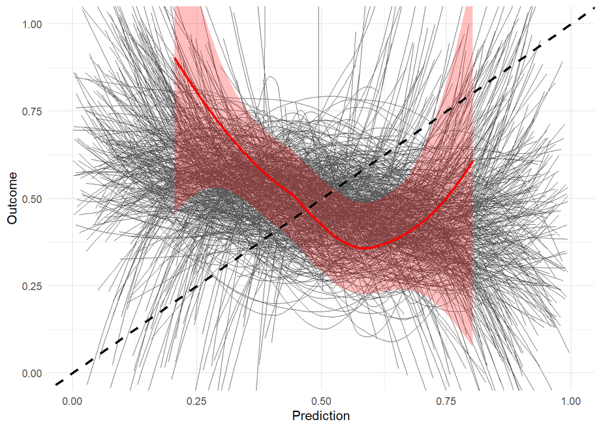

```r
enet_model$plot
```

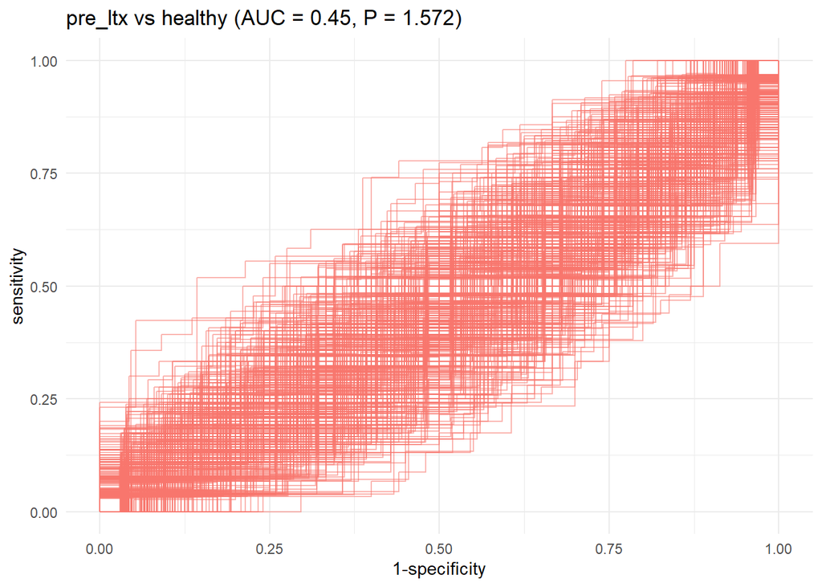

```r
roc_c
```

##### 4.1.1.1.2 pre_ltx vs post_ltx

```r
group <- c("pre_ltx","post_ltx")
comparison_name <- paste0(group[1], " vs ",group[2])
```

```r
model_name <- paste(comparison_name,level,segment)

# prepare the data
filt_ileum_uni_data <- binomial_prep(ileum_genus_tab,
                                     ileum_genus_taxa_tab,
                                     ileum_metadata,
                                     group,
                                     usage="ml_clr")
```

```
Removing 46 ASV(s)
```

```
Removing 6 ASV(s)
```

```r
# fit the model
enet_model <- glmnet_binomial(filt_ileum_uni_data,
                              sample_method = "atypboot",
                              outcome="Group", N=500,
                              reuse=TRUE,
                              file=model_name,
                              Q="Q1",
                              overfitting_check = TRUE)

# ROC
roc_c <- roc_curve(enet_model, group)

# save the results
models_summ[[model_name]] <- enet_model$model_summary
models_cm[[model_name]] <- enet_model$conf_matrices$original
roc_cs[[model_name]] <- enet_model$kfold_rocobjs
betas[[model_name]] <- as.matrix(enet_model$betas)

# see the results
enet_model$model_summary %>% t()
```

```
                                      [,1]
alpha                           1.00000000
lambda                          0.09461542
auc                             0.50000000
auc_czech                       0.50000000
auc_no                          0.50000000
auc_optimism_corrected          0.44402219
auc_optimism_corrected_CIL      0.32593459
auc_optimism_corrected_CIU      0.56059550
accuracy                        0.66346154
accuracy_czech                         NaN
accuracy_no                     0.60975610
accuracy_optimism_corrected     0.58967912
accuracy_optimism_corrected_CIL 0.47400472
accuracy_optimism_corrected_CIU 0.69620253
```

```r
enet_model$conf_matrices
```

```
$original
    0
0 138 0
1  70 0

$czech
   0
0 88 0
1 38 0

$no
   0
0 50 0
1 32 0
```

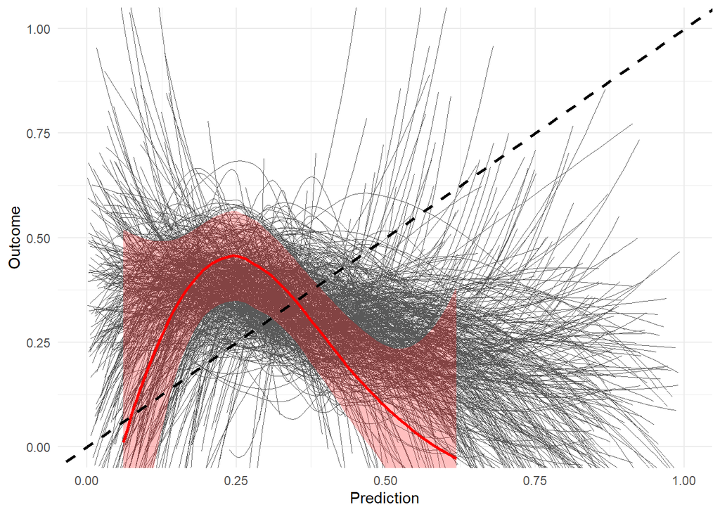

```r
enet_model$plot
```

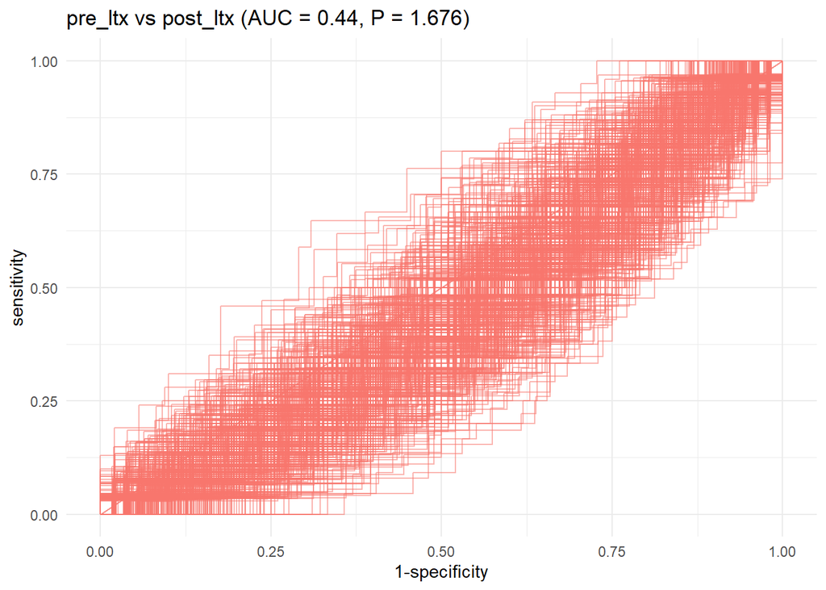

```r
roc_c
```

##### 4.1.1.1.3 post_ltx vs healthy

```r
group <- c("post_ltx","healthy")
comparison_name <- paste0(group[1], " vs ",group[2])
```

```r
model_name <- paste(comparison_name,level,segment)

# prepare the data
filt_ileum_uni_data <- binomial_prep(ileum_genus_tab,
                                     ileum_genus_taxa_tab,
                                     ileum_metadata,group,
                                     usage="ml_clr")
```

```
Removing 45 ASV(s)
```

```
Removing 2 ASV(s)
```

```r
# fit the model
enet_model <- glmnet_binomial(filt_ileum_uni_data,
                              sample_method = "atypboot",
                              outcome="Group",
                              N=500,
                              reuse=TRUE,
                              file=model_name,
                              Q="Q1",
                              overfitting_check = TRUE)

# ROC
roc_c <- roc_curve(enet_model, group)

# save the results
models_summ[[model_name]] <- enet_model$model_summary
models_cm[[model_name]] <- enet_model$conf_matrices$original
roc_cs[[model_name]] <- enet_model$kfold_rocobjs
betas[[model_name]] <- as.matrix(enet_model$betas)

# see the results
enet_model$model_summary %>% t()
```

```
                                      [,1]
alpha                            0.0000000
lambda                          81.9195172
auc                              0.7156045
auc_czech                        0.6625641
auc_no                           0.7407121
auc_optimism_corrected           0.5175379
auc_optimism_corrected_CIL       0.3928180
auc_optimism_corrected_CIU       0.6223579
accuracy                         0.6540284
accuracy_czech                         NaN
accuracy_no                      0.5277778
accuracy_optimism_corrected      0.6017558
accuracy_optimism_corrected_CIL  0.5136918
accuracy_optimism_corrected_CIU  0.7006818
```

```r
enet_model$conf_matrices
```

```
$original
    1
0  73 0
1 138 0

$czech
    1
0  39 0
1 100 0

$no
   1
0 34 0
1 38 0
```

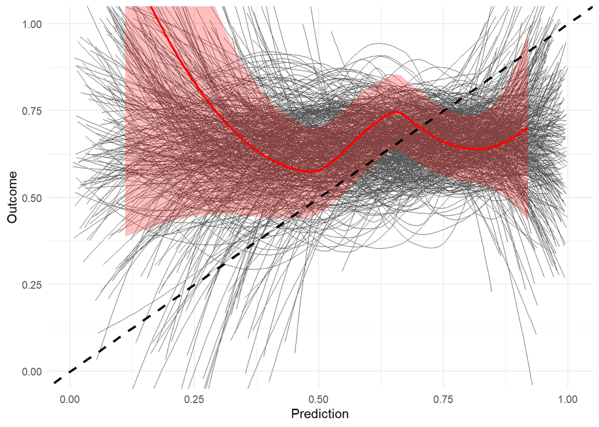

```r
enet_model$plot
```

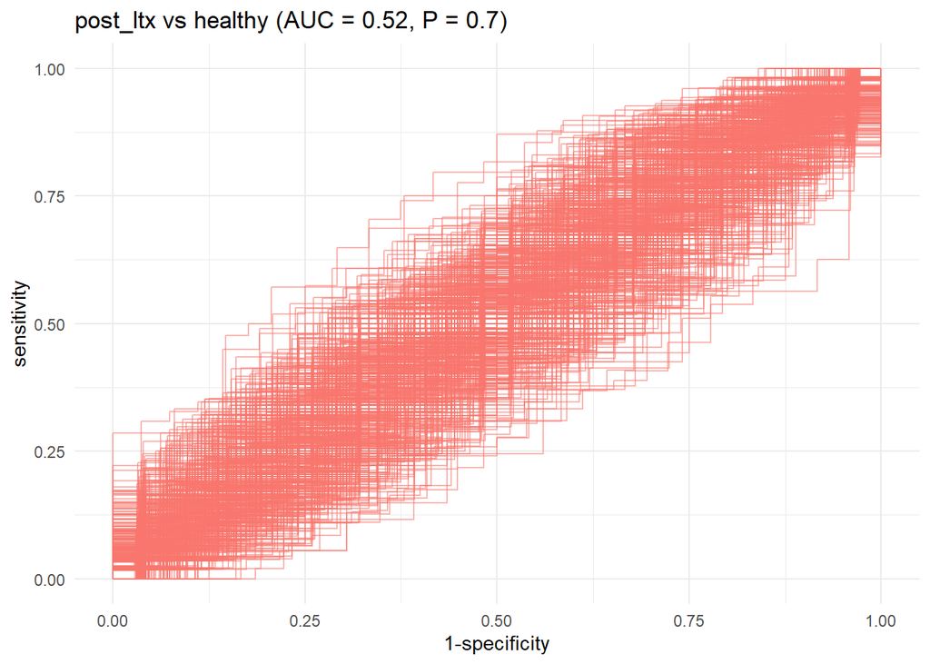

```r
roc_c
```

#### 4.1.1.2 Saving results

```r
models_summ_df_ileum <- do.call(rbind,
  models_summ[grep(segment,names(models_summ),value = TRUE)])

write.csv(models_summ_df_ileum,file.path(path,paste0("elastic_net_",segment,".csv")))
```

### 4.1.2 Supplementary models

```r
supplements_models <- list()
```

#### 4.1.2.1 CLR-transformed data

##### 4.1.2.1.1 kNN

```r
model="knn"
```

###### 4.1.2.1.1.1 Genus level

```r
level="genus"
```

Aggregate taxa

```r
genus_data <- aggregate_taxa(ileum_asv_tab,
                             ileum_taxa_tab,
                             taxonomic_level = level)

ileum_genus_tab <- genus_data[[1]]
ileum_genus_taxa_tab <- genus_data[[2]]
```

**pre_ltx vs healthy**

```r
group <- c("pre_ltx","healthy")
comparison_name <- paste0(group[1], " vs ",group[2])
```

```r
model_name <- paste(comparison_name,level,segment)

# prepare the data
filt_ileum_uni_data <- binomial_prep(ileum_genus_tab,
                                     ileum_genus_taxa_tab,
                                     ileum_metadata,
                                     group,
                                     usage="ml_clr")
```

```
Removing 84 ASV(s)
```

```
Removing 10 ASV(s)
```

```r
# fit the model
knn_model <- knn_binomial(filt_ileum_uni_data,
                              sample_method = "atypboot",
                              outcome="Group",
                              N=500,
                              reuse=TRUE,
                              file=model_name,
                              Q="Q1",
                              overfitting_check = TRUE)

# ROC curve
roc_c <- roc_curve(knn_model, group)

# save the results
supplements_models[["models_summ"]][["knn_model"]][[model_name]] <- knn_model$model_summary
supplements_models[["roc_cs"]][["knn_model"]][[model_name]] <- knn_model$kfold_rocobjs


# see the results
knn_model$model_summary %>% t()
```

```
                                      [,1]
k                               13.0000000
auc                              0.6862035
auc_optimism_corrected           0.5110905
auc_optimism_corrected_CIL       0.3610817
auc_optimism_corrected_CIU       0.6615794
accuracy                         0.5874126
accuracy_optimism_corrected      0.4977140
accuracy_optimism_corrected_CIL  0.3796379
accuracy_optimism_corrected_CIU  0.6226415
```

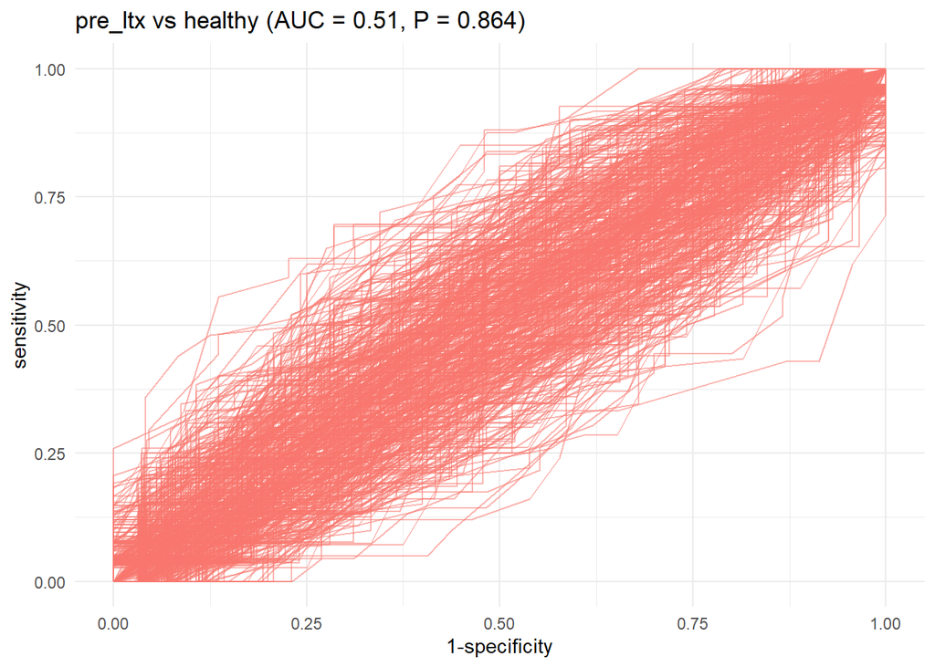

```r
roc_c
```

**pre_ltx vs post_ltx**

```r
group <- c("pre_ltx","post_ltx")
comparison_name <- paste0(group[1], " vs ",group[2])
```

```r
model_name <- paste(comparison_name,level,segment)

# prepare the data
filt_ileum_uni_data <- binomial_prep(ileum_genus_tab,
                                     ileum_genus_taxa_tab,
                                     ileum_metadata,
                                     group,
                                     usage="ml_clr")
```

```
Removing 46 ASV(s)
```

```
Removing 6 ASV(s)
```

```r
# fit the model
knn_model <- knn_binomial(filt_ileum_uni_data,
                              sample_method = "atypboot",
                              outcome="Group",
                              N=500,
                              reuse=TRUE,
                              file=model_name,
                              Q="Q1",
                              overfitting_check = TRUE)

# ROC curve
roc_c <- roc_curve(knn_model, group)

# save the results
supplements_models[["models_summ"]][["knn_model"]][[model_name]] <- knn_model$model_summary
supplements_models[["roc_cs"]][["knn_model"]][[model_name]] <- knn_model$kfold_rocobjs


# see the results
knn_model$model_summary %>% t()
```

```
                                      [,1]
k                               27.0000000
auc                              0.5889752
auc_optimism_corrected           0.4685397
auc_optimism_corrected_CIL       0.3548958
auc_optimism_corrected_CIU       0.5926814
accuracy                         0.6634615
accuracy_optimism_corrected      0.6286877
accuracy_optimism_corrected_CIL  0.5218434
accuracy_optimism_corrected_CIU  0.7080288
```

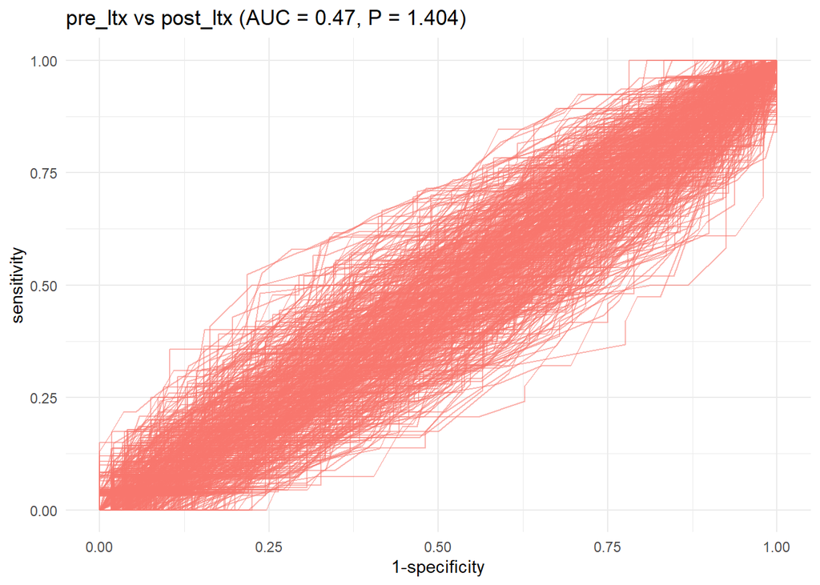

```r
roc_c
```

**post_ltx vs healthy**

```r
group <- c("post_ltx","healthy")
comparison_name <- paste0(group[1], " vs ",group[2])
```

```r
model_name <- paste(comparison_name,level,segment)

# prepare the data
filt_ileum_uni_data <- binomial_prep(ileum_genus_tab,
                                     ileum_genus_taxa_tab,
                                     ileum_metadata,
                                     group,
                                     usage="ml_clr")
```

```
Removing 45 ASV(s)
```

```
Removing 2 ASV(s)
```

```r
# fit the model
knn_model <- knn_binomial(filt_ileum_uni_data,
                              sample_method = "atypboot",
                              outcome="Group",
                              N=500,
                              reuse=TRUE,
                              file=model_name,
                              Q="Q1",
                              overfitting_check = TRUE)

# ROC curve
roc_c <- roc_curve(knn_model, group)

# save the results
supplements_models[["models_summ"]][["knn_model"]][[model_name]] <- knn_model$model_summary
supplements_models[["roc_cs"]][["knn_model"]][[model_name]] <- knn_model$kfold_rocobjs


# see the results
knn_model$model_summary %>% t()
```

```
                                      [,1]
k                               21.0000000
auc                              0.5996625
auc_optimism_corrected           0.4792983
auc_optimism_corrected_CIL       0.3537347
auc_optimism_corrected_CIU       0.5968061
accuracy                         0.6872038
accuracy_optimism_corrected      0.5839843
accuracy_optimism_corrected_CIL  0.4670779
accuracy_optimism_corrected_CIU  0.6857902
```

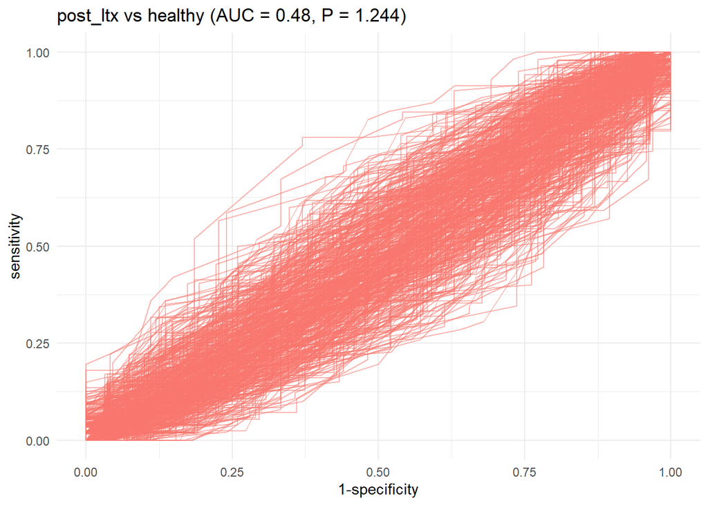

```r
roc_c
```

##### 4.1.2.1.2 RF

```r
model="rf"
```

###### 4.1.2.1.2.1 Genus level

```r
level="genus"
```

Aggregate taxa

```r
genus_data <- aggregate_taxa(ileum_asv_tab,
                             ileum_taxa_tab,
                             taxonomic_level = level)

ileum_genus_tab <- genus_data[[1]]
ileum_genus_taxa_tab <- genus_data[[2]]
```

**pre_ltx vs healthy**

```r
group <- c("pre_ltx","healthy")
comparison_name <- paste0(group[1], " vs ",group[2])
```

```r
model_name <- paste(comparison_name,level,segment)

# prepare the data
filt_ileum_uni_data <- binomial_prep(ileum_genus_tab,
                                     ileum_genus_taxa_tab,
                                     ileum_metadata,
                                     group,
                                     usage="ml_clr")
```

```
Removing 84 ASV(s)
```

```
Removing 10 ASV(s)
```

```r
# fit the model
rf_model <- rf_binomial(filt_ileum_uni_data,
                              sample_method = "atypboot",
                              outcome="Group",
                              N=500,
                              reuse=TRUE,
                              file=model_name,
                              Q="Q1",
                              overfitting_check = TRUE)

# ROC curve
roc_c <- roc_curve(rf_model, group)

# save the results
supplements_models[["models_summ"]][["rf_model"]][[model_name]] <- rf_model$model_summary
supplements_models[["roc_cs"]][["rf_model"]][[model_name]] <- rf_model$kfold_rocobjs

# see the results
rf_model$model_summary %>% t()
```

```
                                [,1]
mtry                            "177"
splitrule                       "gini"
min.node.size                   "5"
auc                             "1"
auc_optimism_corrected          "0.4369043"
auc_optimism_corrected_CIL      "0.2979512"
auc_optimism_corrected_CIU      "0.5754973"
accuracy                        "1"
accuracy_optimism_corrected     "0.4466668"
accuracy_optimism_corrected_CIL "0.3333333"
accuracy_optimism_corrected_CIU "0.5643573"
```

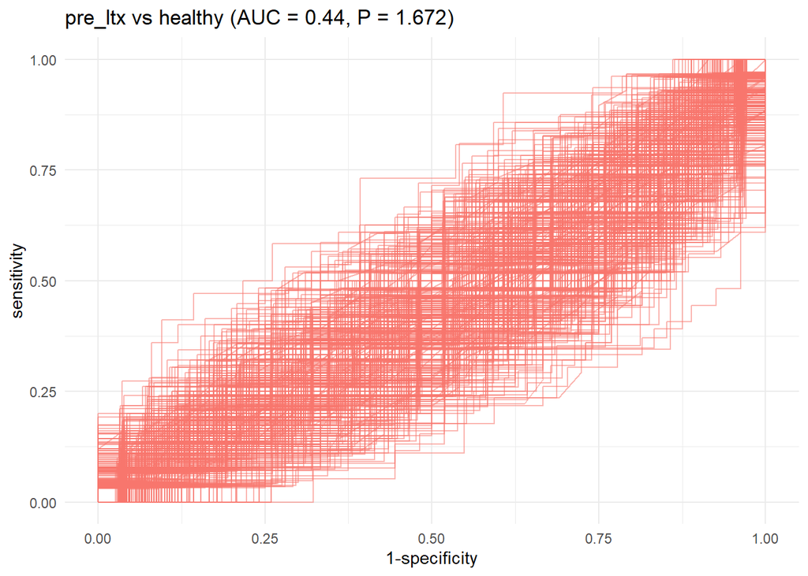

```r
roc_c
```

**pre_ltx vs post_ltx**

```r
group <- c("pre_ltx","post_ltx")
comparison_name <- paste0(group[1], " vs ",group[2])
```

```r
model_name <- paste(comparison_name,level,segment)

# prepare the data
filt_ileum_uni_data <- binomial_prep(ileum_genus_tab,
                                     ileum_genus_taxa_tab,
                                     ileum_metadata,
                                     group,
                                     usage="ml_clr")
```

```
Removing 46 ASV(s)
```

```
Removing 6 ASV(s)
```

```r
# fit the model
rf_model <- rf_binomial(filt_ileum_uni_data,
                              sample_method = "atypboot",
                              outcome="Group",
                              N=500,
                              reuse=TRUE,
                              file=model_name,
                              Q="Q1",
                              overfitting_check = TRUE)

# ROC curve
roc_c <- roc_curve(rf_model, group)

# save the results
supplements_models[["models_summ"]][["rf_model"]][[model_name]] <- rf_model$model_summary
supplements_models[["roc_cs"]][["rf_model"]][[model_name]] <- rf_model$kfold_rocobjs

# see the results
rf_model$model_summary %>% t()
```

```
                                [,1]
mtry                            "25"
splitrule                       "gini"
min.node.size                   "5"
auc                             "1"
auc_optimism_corrected          "0.4166664"
auc_optimism_corrected_CIL      "0.3120122"
auc_optimism_corrected_CIU      "0.5166617"
accuracy                        "1"
accuracy_optimism_corrected     "0.5963562"
accuracy_optimism_corrected_CIL "0.5152902"
accuracy_optimism_corrected_CIU "0.6762738"
```

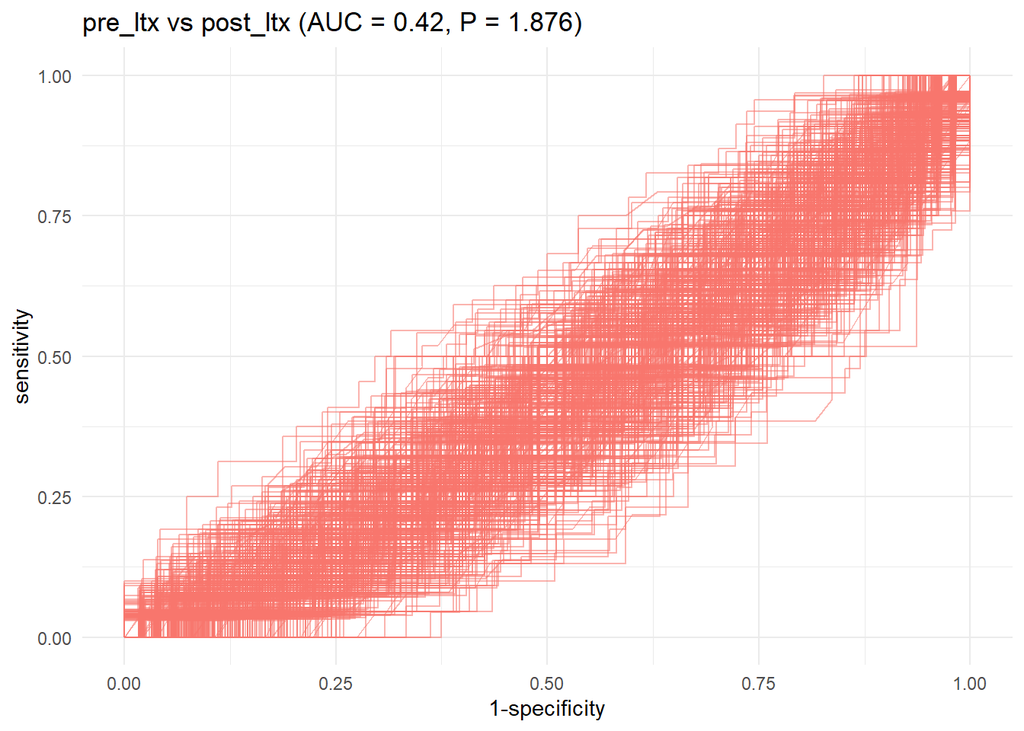

```r
roc_c
```

**post_ltx vs healthy**

```r
group <- c("post_ltx","healthy")
comparison_name <- paste0(group[1], " vs ",group[2])
```

```r
model_name <- paste(comparison_name,level,segment)

# prepare the data
filt_ileum_uni_data <- binomial_prep(ileum_genus_tab,
                                     ileum_genus_taxa_tab,
                                     ileum_metadata,
                                     group,
                                     usage="ml_clr")
```

```
Removing 45 ASV(s)
```

```
Removing 2 ASV(s)
```

```r
# fit the model
rf_model <- rf_binomial(filt_ileum_uni_data,
                              sample_method = "atypboot",
                              outcome="Group",
                              N=500,
                              reuse=TRUE,
                              file=model_name,
                              Q="Q1",
                              overfitting_check = TRUE)

# ROC curve
roc_c <- roc_curve(rf_model, group)

# save the results
supplements_models[["models_summ"]][["rf_model"]][[model_name]] <- rf_model$model_summary
supplements_models[["roc_cs"]][["rf_model"]][[model_name]] <- rf_model$kfold_rocobjs

# see the results
rf_model$model_summary %>% t()
```

```
                                [,1]
mtry                            "1"
splitrule                       "gini"
min.node.size                   "5"
auc                             "1"
auc_optimism_corrected          "0.4759634"
auc_optimism_corrected_CIL      "0.3675048"
auc_optimism_corrected_CIU      "0.5945952"
accuracy                        "1"
accuracy_optimism_corrected     "0.595825"
accuracy_optimism_corrected_CIL "0.4938978"
accuracy_optimism_corrected_CIU "0.6783764"
```

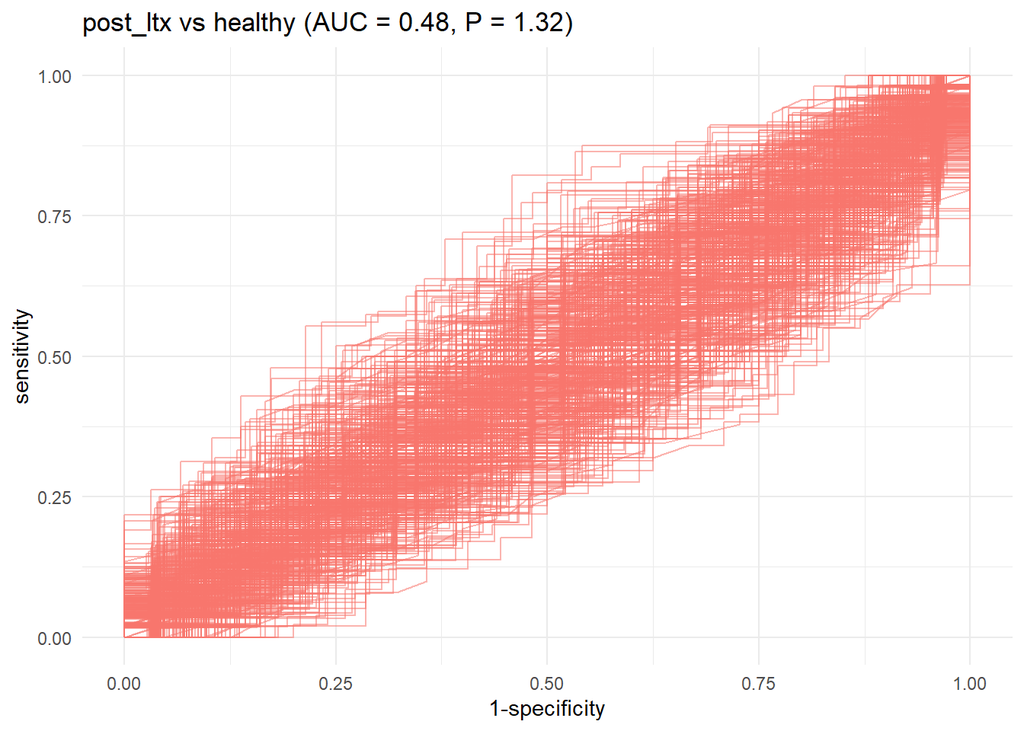

```r
roc_c
```

##### 4.1.2.1.3 GBoost

```r
model="gb"
```

###### 4.1.2.1.3.1 Genus level

```r
level="genus"
```

Aggregate taxa

```r
genus_data <- aggregate_taxa(ileum_asv_tab,
                             ileum_taxa_tab,
                             taxonomic_level = level)

ileum_genus_tab <- genus_data[[1]]
ileum_genus_taxa_tab <- genus_data[[2]]
```

**pre_ltx vs healthy**

```r
group <- c("pre_ltx","healthy")
comparison_name <- paste0(group[1], " vs ",group[2])
```

```r
model_name <- paste(comparison_name,level,segment)

# prepare the data
filt_ileum_uni_data <- binomial_prep(ileum_genus_tab,
                                     ileum_genus_taxa_tab,
                                     ileum_metadata,
                                     group,
                                     usage="ml_clr")
```

```
Removing 84 ASV(s)
```

```
Removing 10 ASV(s)
```

```r
# fit the model
gbm_model <- gbm_binomial(filt_ileum_uni_data,
                              sample_method = "atypboot",
                              outcome="Group",
                              N=500,
                              reuse=TRUE,
                              file=model_name,
                              Q="Q1",
                              overfitting_check = TRUE)

# ROC curve
roc_c <- roc_curve(gbm_model, group)

# save the results
supplements_models[["models_summ"]][["gbm_model"]][[model_name]] <- gbm_model$model_summary
supplements_models[["roc_cs"]][["gbm_model"]][[model_name]] <- gbm_model$kfold_rocobjs

# see the results
gbm_model$model_summary %>% t()
```

```
                                       [,1]
n.trees                         500.0000000
interaction.depth                 1.0000000
shrinkage                         0.1000000
n.minobsinnode                   20.0000000
auc                               1.0000000
auc_optimism_corrected            0.4316582
auc_optimism_corrected_CIL        0.2936529
auc_optimism_corrected_CIU        0.5382335
accuracy                          1.0000000
accuracy_optimism_corrected       0.4507677
accuracy_optimism_corrected_CIL   0.3274216
accuracy_optimism_corrected_CIU   0.5660377
```

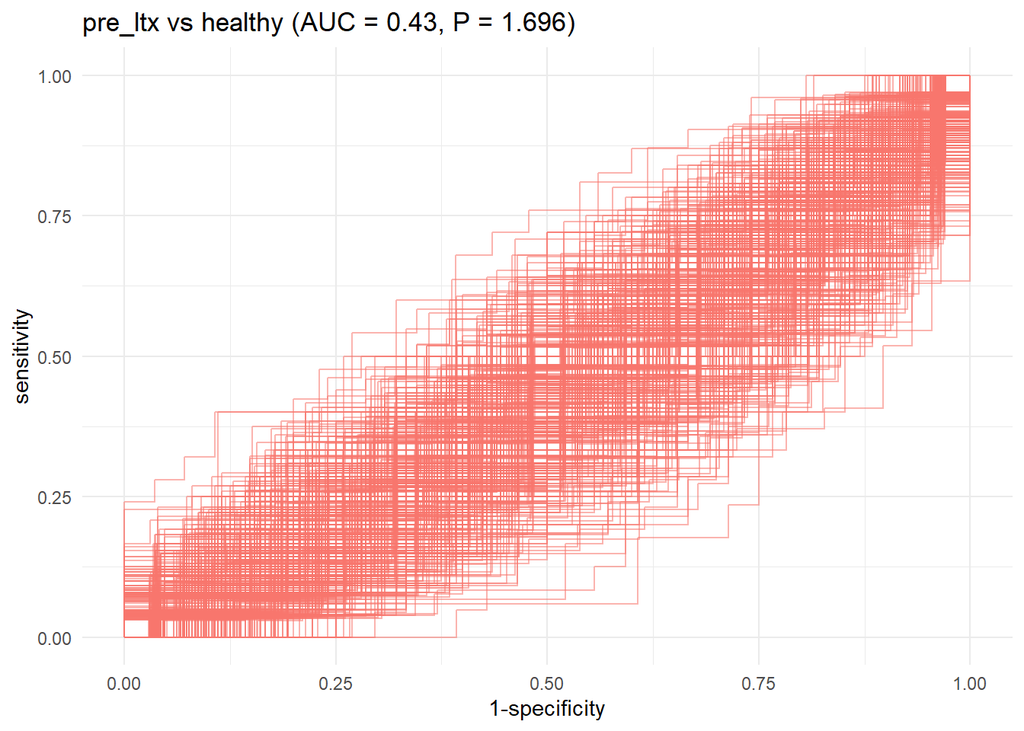

```r
roc_c
```

**pre_ltx vs post_ltx**

```r
group <- c("pre_ltx","post_ltx")
comparison_name <- paste0(group[1], " vs ",group[2])
```

```r
model_name <- paste(comparison_name,level,segment)

# prepare the data
filt_ileum_uni_data <- binomial_prep(ileum_genus_tab,
                                     ileum_genus_taxa_tab,
                                     ileum_metadata,
                                     group,
                                     usage="ml_clr")
```

```
Removing 46 ASV(s)
```

```
Removing 6 ASV(s)
```

```r
# fit the model
gbm_model <- gbm_binomial(filt_ileum_uni_data,
                              sample_method = "atypboot",
                              outcome="Group",
                              N=500,
                              reuse=TRUE,
                              file=model_name,
                              Q="Q1",
                              overfitting_check = TRUE)

# ROC curve
roc_c <- roc_curve(gbm_model, group)

# save the results
supplements_models[["models_summ"]][["gbm_model"]][[model_name]] <- gbm_model$model_summary
supplements_models[["roc_cs"]][["gbm_model"]][[model_name]] <- gbm_model$kfold_rocobjs

# see the results
gbm_model$model_summary %>% t()
```

```
                                       [,1]
n.trees                         500.0000000
interaction.depth                 1.0000000
shrinkage                         0.1000000
n.minobsinnode                   20.0000000
auc                               1.0000000
auc_optimism_corrected            0.5006084
auc_optimism_corrected_CIL        0.3838311
auc_optimism_corrected_CIU        0.6216013
accuracy                          1.0000000
accuracy_optimism_corrected       0.6020980
accuracy_optimism_corrected_CIL   0.5068451
accuracy_optimism_corrected_CIU   0.6918566
```

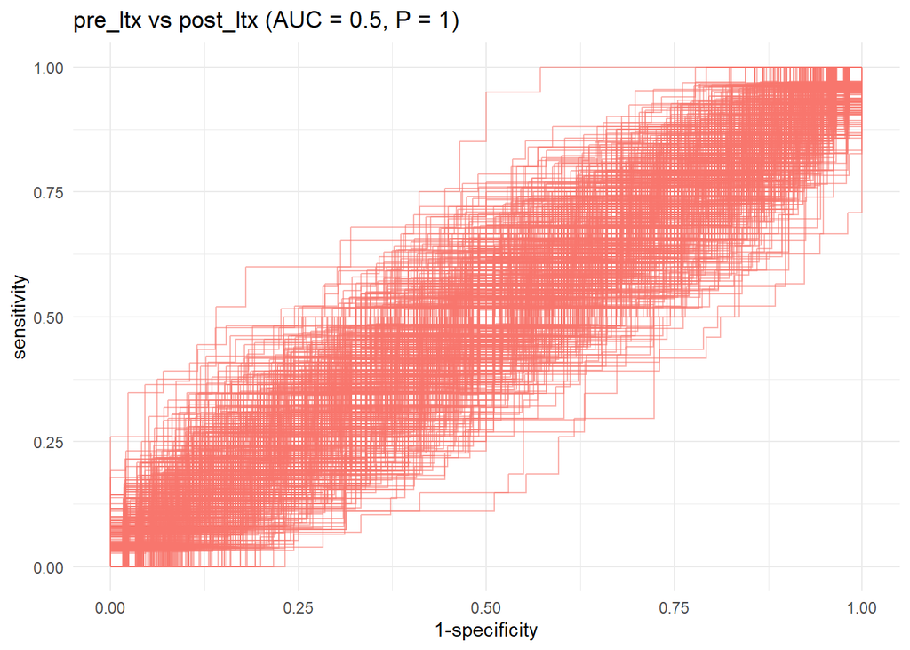

```r
roc_c
```

**post_ltx vs healthy**

```r
group <- c("post_ltx","healthy")
comparison_name <- paste0(group[1], " vs ",group[2])
```

```r
model_name <- paste(comparison_name,level,segment)

# prepare the data
filt_ileum_uni_data <- binomial_prep(ileum_genus_tab,
                                     ileum_genus_taxa_tab,
                                     ileum_metadata,
                                     group,
                                     usage="ml_clr")
```

```
Removing 45 ASV(s)
```

```
Removing 2 ASV(s)
```

```r
# fit the model
gbm_model <- gbm_binomial(filt_ileum_uni_data,
                              sample_method = "atypboot",
                              outcome="Group",
                              N=500,
                              reuse=TRUE,
                              file=model_name,
                              Q="Q1",
                              overfitting_check = TRUE)

# ROC curve
roc_c <- roc_curve(gbm_model, group)

# save the results
supplements_models[["models_summ"]][["gbm_model"]][[model_name]] <- gbm_model$model_summary
supplements_models[["roc_cs"]][["gbm_model"]][[model_name]] <- gbm_model$kfold_rocobjs

# see the results
gbm_model$model_summary %>% t()
```

```
                                       [,1]
n.trees                         200.0000000
interaction.depth                 1.0000000
shrinkage                         0.1000000
n.minobsinnode                   10.0000000
auc                               0.9998015
auc_optimism_corrected            0.5728982
auc_optimism_corrected_CIL        0.4579271
auc_optimism_corrected_CIU        0.6886252
accuracy                          0.9715640
accuracy_optimism_corrected       0.5907432
accuracy_optimism_corrected_CIL   0.4967593
accuracy_optimism_corrected_CIU   0.6845890
```

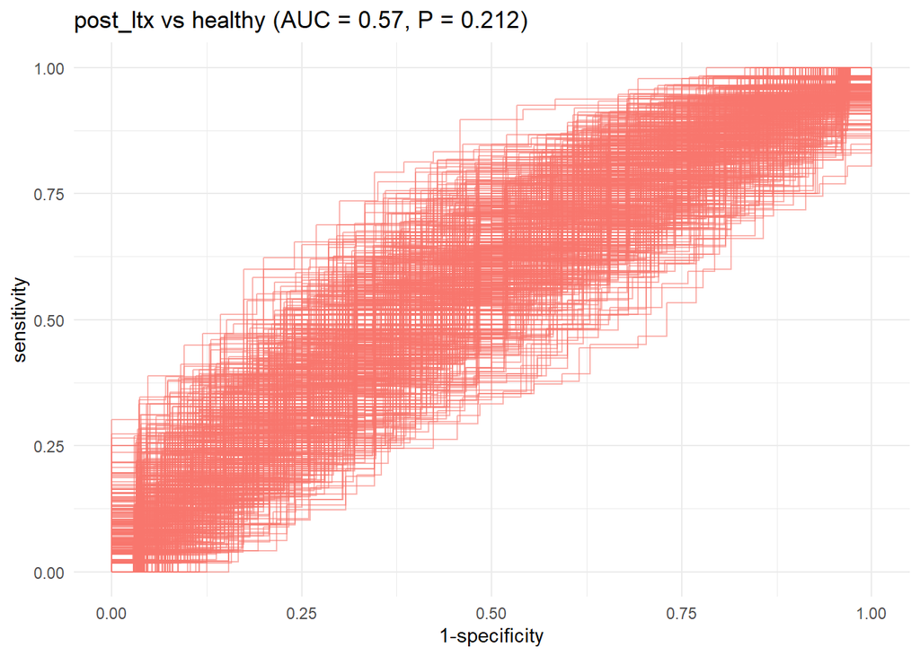

```r
roc_c
```

#### 4.1.2.2 Saving results

```r
models_list <- list()

for (model_name in names(supplements_models$models_summ)){
  df <- do.call(rbind, supplements_models$models_summ[[model_name]])
  models_list[[model_name]] <- df
}

write.xlsx(models_list,
           file=file.path(path,paste0("supplements_models_",segment,".xlsx")),
           rowNames=TRUE)
```

# 5 Data Analysis - Colon

```r
segment="colon"
```

## 5.1 Machine learning

```r
path = "../results/Q1/models_overfitting_check"
```

### 5.1.1 ENET

```r
model="enet"
```

#### 5.1.1.1 Genus level

```r
level="genus"
```

Aggregate taxa

```r
genus_data <- aggregate_taxa(colon_asv_tab,
                             colon_taxa_tab,
                             taxonomic_level = level)

colon_genus_tab <- genus_data[[1]]
colon_genus_taxa_tab <- genus_data[[2]]
```

##### 5.1.1.1.1 pre_ltx vs healthy

```r
group <- c("pre_ltx","healthy")
comparison_name <- paste0(group[1], " vs ",group[2])
```

```r
model_name <- paste(comparison_name,level,segment)

# prepare the data
filt_colon_uni_data <- binomial_prep(colon_genus_tab,
                                     colon_genus_taxa_tab,
                                     colon_metadata,
                                     group,
                                     usage="ml_clr",
                                     patient = TRUE)
```

```
Removing 135 ASV(s)
```

```
Removing 10 ASV(s)
```

```r
# fit the model
enet_model <- glmnet_binomial(filt_colon_uni_data,
                              sample_method = "atypboot",
                              outcome="Group",
                              N=500,
                              clust_var="Patient",
                              reuse=TRUE,
                              file=model_name,
                              Q="Q1",overfitting_check = TRUE)


# ROC
roc_c <- roc_curve(enet_model, group)

# save the results
models_summ[[model_name]] <- enet_model$model_summary
models_cm[[model_name]] <- enet_model$conf_matrices$original
roc_cs[[model_name]] <- enet_model$kfold_rocobjs
betas[[model_name]] <- as.matrix(enet_model$betas)

# see the results
enet_model$model_summary %>% t()
```

```
                                     [,1]
alpha                           0.6000000
lambda                          0.1142179
auc                             0.5653292
auc_czech                       0.5312098
auc_no                          0.5910540
auc_optimism_corrected          0.5004172
auc_optimism_corrected_CIL      0.4204680
auc_optimism_corrected_CIU      0.5823541
accuracy                        0.6082725
accuracy_czech                        NaN
accuracy_no                     0.6423358
accuracy_optimism_corrected     0.5655580
accuracy_optimism_corrected_CIL 0.4813607
accuracy_optimism_corrected_CIU 0.6341662
```

```r
enet_model$conf_matrices
```

```
$original
    1
0 161 0
1 250 0

$czech
   1
0 63 0
1 74 0

$no
    1
0  98 0
1 176 0
```

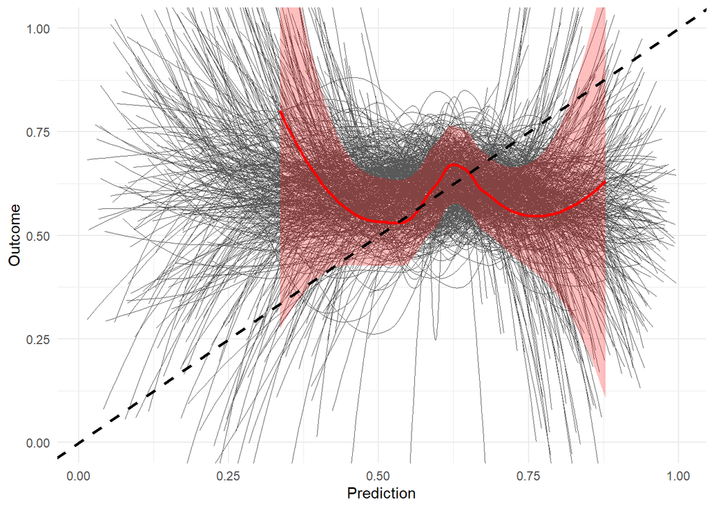

```r
enet_model$plot
```

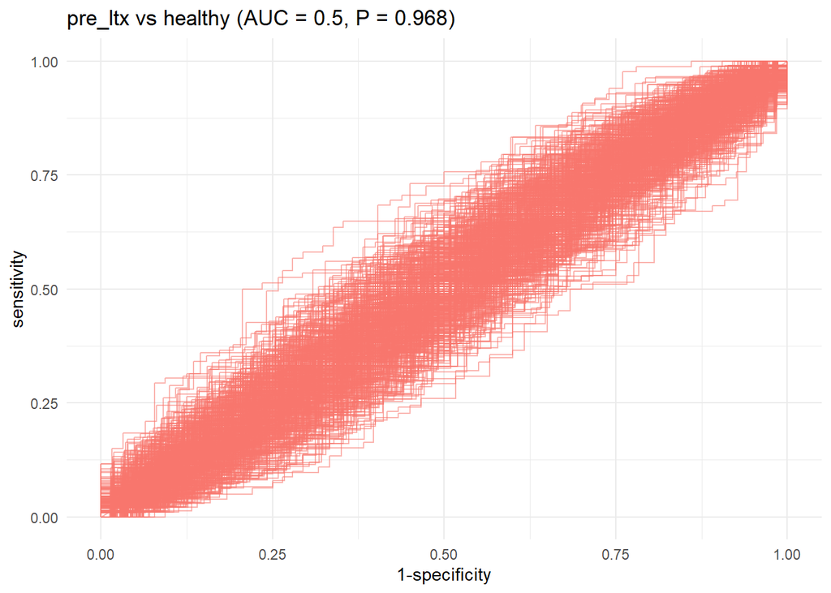

```r
roc_c
```

##### 5.1.1.1.2 pre_ltx vs post_ltx

```r
group <- c("pre_ltx","post_ltx")
comparison_name <- paste0(group[1], " vs ",group[2])
```

```r
model_name <- paste(comparison_name,level,segment)

# prepare the data
filt_colon_uni_data <- binomial_prep(colon_genus_tab,
                                     colon_genus_taxa_tab,
                                     colon_metadata,
                                     group,
                                     usage="ml_clr",
                                     patient = TRUE)
```

```
Removing 17 ASV(s)
```

```
Removing 10 ASV(s)
```

```r
# fit the model
enet_model <- glmnet_binomial(filt_colon_uni_data,
                              sample_method = "atypboot",
                              outcome="Group",
                              N=500,
                              clust_var="Patient",
                              reuse=TRUE,
                              file=model_name,
                              Q="Q1",
                              overfitting_check = TRUE)

# ROC
roc_c <- roc_curve(enet_model, group)

# save the results
models_summ[[model_name]] <- enet_model$model_summary
models_cm[[model_name]] <- enet_model$conf_matrices$original
roc_cs[[model_name]] <- enet_model$kfold_rocobjs
betas[[model_name]] <- as.matrix(enet_model$betas)

# see the results
enet_model$model_summary %>% t()
```

```
                                      [,1]
alpha                            0.0000000
lambda                          55.8015092
auc                              0.6231771
auc_czech                        0.6506435
auc_no                           0.6103118
auc_optimism_corrected           0.4986184
auc_optimism_corrected_CIL       0.4393670
auc_optimism_corrected_CIU       0.5579272
accuracy                         0.5833333
accuracy_czech                         NaN
accuracy_no                      0.6017192
accuracy_optimism_corrected      0.5620984
accuracy_optimism_corrected_CIL  0.5000000
accuracy_optimism_corrected_CIU  0.6269051
```

```r
enet_model$conf_matrices
```

```
$original
    0
0 350 0
1 250 0

$czech
    0
0 140 0
1 111 0

$no
    0
0 210 0
1 139 0
```

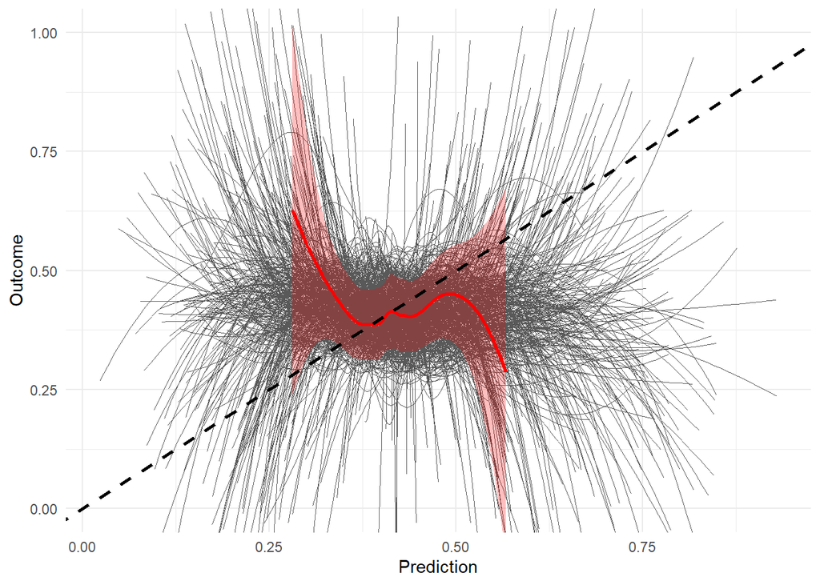

```r
enet_model$plot
```

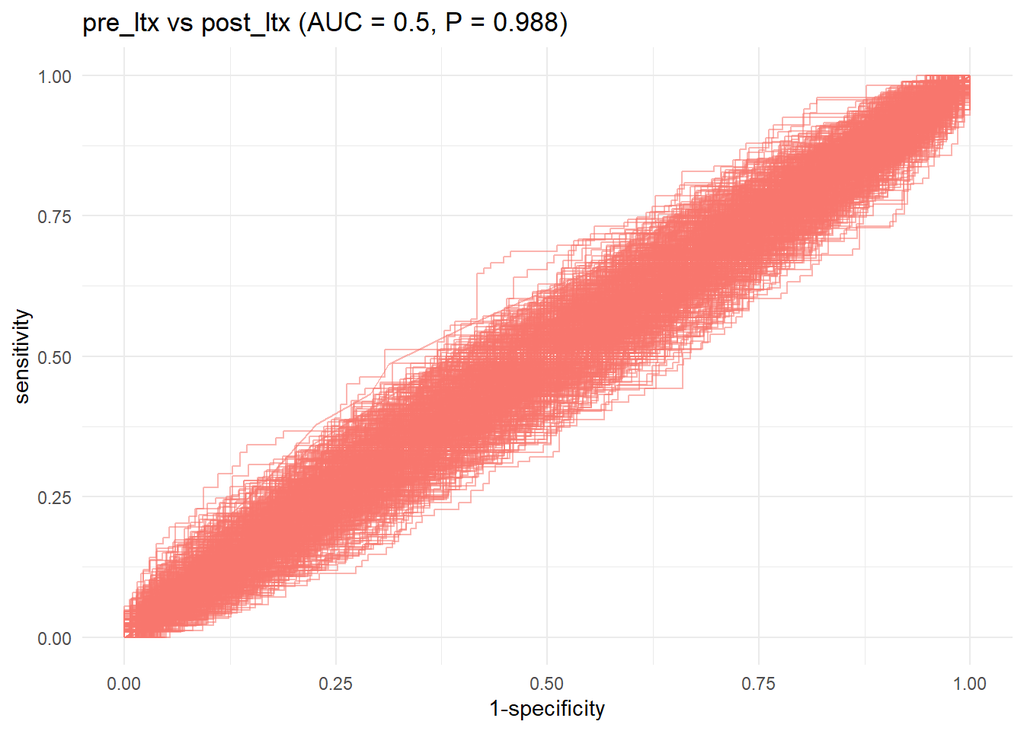

```r
roc_c
```

##### 5.1.1.1.3 post_ltx vs healthy

```r
group <- c("post_ltx","healthy")
comparison_name <- paste0(group[1], " vs ",group[2])
```

```r
model_name <- paste(comparison_name,level,segment)

# prepare the data
filt_colon_uni_data <- binomial_prep(colon_genus_tab,
                                     colon_genus_taxa_tab,
                                     colon_metadata,
                                     group,
                                     usage="ml_clr",
                                     patient = TRUE)
```

```
Removing 71 ASV(s)
```

```
Removing 5 ASV(s)
```

```r
# fit the model
enet_model <- glmnet_binomial(filt_colon_uni_data,
                              sample_method = "atypboot",
                              outcome="Group",
                              N=500,
                              clust_var="Patient",
                              reuse=TRUE,
                              file=model_name,
                              Q="Q1",
                              overfitting_check = TRUE)

# ROC
roc_c <- roc_curve(enet_model, group)

# save the results
models_summ[[model_name]] <- enet_model$model_summary
models_cm[[model_name]] <- enet_model$conf_matrices$original
roc_cs[[model_name]] <- enet_model$kfold_rocobjs
betas[[model_name]] <- as.matrix(enet_model$betas)

# see the results
enet_model$model_summary %>% t()
```

```
                                      [,1]
alpha                            0.0000000
lambda                          59.1733127
auc                              0.6228039
auc_czech                        0.5983574
auc_no                           0.6619718
auc_optimism_corrected           0.4917990
auc_optimism_corrected_CIL       0.4149382
auc_optimism_corrected_CIU       0.5685243
accuracy                         0.6849315
accuracy_czech                         NaN
accuracy_no                      0.6859903
accuracy_optimism_corrected      0.6668773
accuracy_optimism_corrected_CIL  0.6040824
accuracy_optimism_corrected_CIU  0.7232358
```

```r
enet_model$conf_matrices
```

```
$original
    1
0 161 0
1 350 0

$czech
    1
0  96 0
1 208 0

$no
    1
0  65 0
1 142 0
```

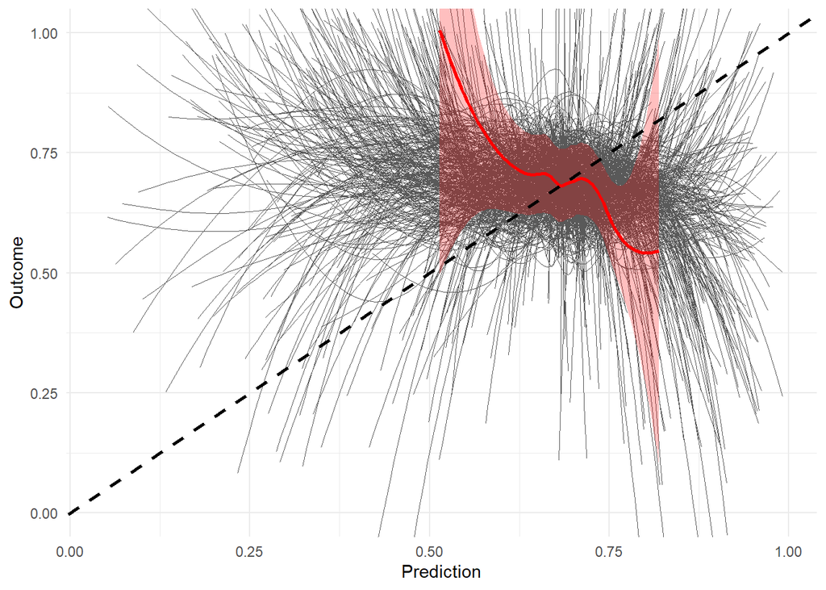

```r
enet_model$plot
```

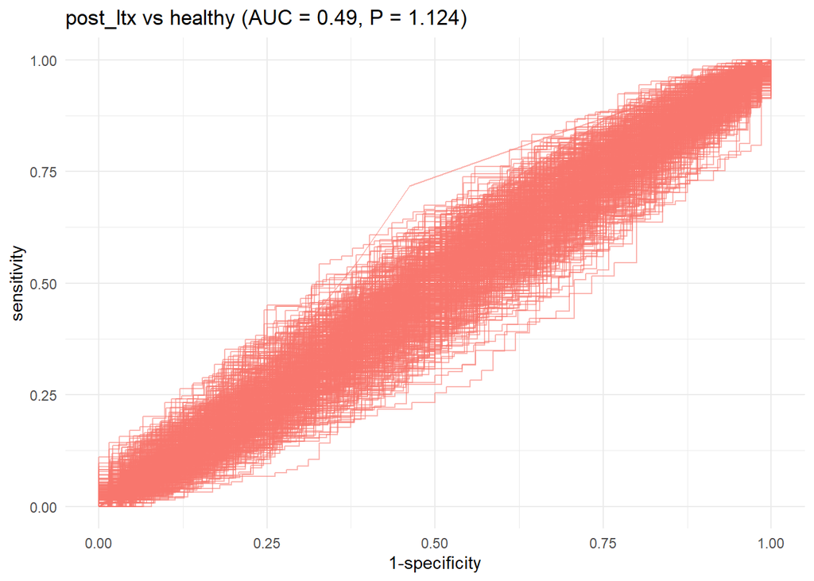

```r
roc_c
```

#### 5.1.1.2 Saving results

```r
models_summ_df_colon <- do.call(rbind,
  models_summ[grep(segment,names(models_summ),value = TRUE)])

write.csv(models_summ_df_colon,file.path(path,paste0("elastic_net_",segment,".csv")))
```

### 5.1.2 Supplementary models

#### 5.1.2.1 CLR-transformed data

##### 5.1.2.1.1 kNN

```r
model="knn"
```

###### 5.1.2.1.1.1 Genus level

```r
level="genus"
```

Aggregate taxa

```r
genus_data <- aggregate_taxa(colon_asv_tab,
                             colon_taxa_tab,
                             taxonomic_level = level)

colon_genus_tab <- genus_data[[1]]
colon_genus_taxa_tab <- genus_data[[2]]
```

**pre_ltx vs healthy**

```r
group <- c("pre_ltx","healthy")
comparison_name <- paste0(group[1], " vs ",group[2])
```

```r
model_name <- paste(comparison_name,level,segment)

# prepare the data
filt_colon_uni_data <- binomial_prep(colon_genus_tab,
                                     colon_genus_taxa_tab,
                                     colon_metadata,
                                     group,
                                     usage="ml_clr",
                                     patient = TRUE)
```

```
Removing 135 ASV(s)
```

```
Removing 10 ASV(s)
```

```r
# fit the model
knn_model <- knn_binomial(filt_colon_uni_data,
                              sample_method = "atypboot",
                              outcome="Group",
                              N=500,
                          clust_var="Patient",
                              reuse=TRUE,
                              file=model_name,
                              Q="Q1",
                          overfitting_check = TRUE)

# ROC curve
roc_c <- roc_curve(knn_model, group)

# save the results
supplements_models[["models_summ"]][["knn_model"]][[model_name]] <- knn_model$model_summary
supplements_models[["roc_cs"]][["knn_model"]][[model_name]] <- knn_model$kfold_rocobjs


# see the results
knn_model$model_summary %>% t()
```

```
                                      [,1]
k                               27.0000000
auc                              0.6238261
auc_optimism_corrected           0.4942465
auc_optimism_corrected_CIL       0.3970386
auc_optimism_corrected_CIU       0.5861549
accuracy                         0.6277372
accuracy_optimism_corrected      0.5315829
accuracy_optimism_corrected_CIL  0.4477612
accuracy_optimism_corrected_CIU  0.6114949
```

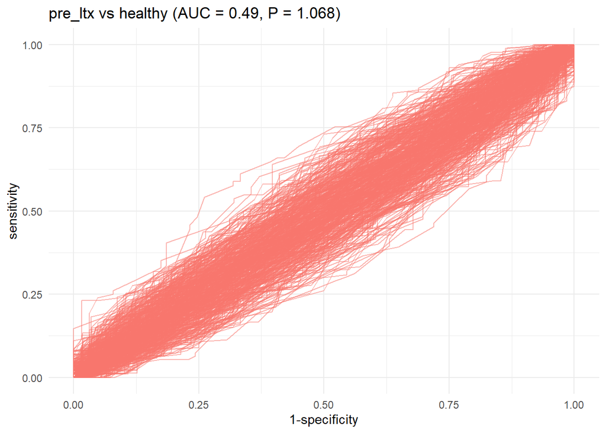

```r
roc_c
```

**pre_ltx vs post_ltx**

```r
group <- c("pre_ltx","post_ltx")
comparison_name <- paste0(group[1], " vs ",group[2])
```

```r
model_name <- paste(comparison_name,level,segment)

# prepare the data
filt_colon_uni_data <- binomial_prep(colon_genus_tab,
                                     colon_genus_taxa_tab,
                                     colon_metadata,
                                     group,
                                     usage="ml_clr",
                                     patient = TRUE)
```

```
Removing 17 ASV(s)
```

```
Removing 10 ASV(s)
```

```r
# fit the model
knn_model <- knn_binomial(filt_colon_uni_data,
                              sample_method = "atypboot",
                              outcome="Group",
                              N=500,
                          clust_var="Patient",
                              reuse=TRUE,
                              file=model_name,
                              Q="Q1",
                          overfitting_check = TRUE)

# ROC curve
roc_c <- roc_curve(knn_model, group)

# save the results
supplements_models[["models_summ"]][["knn_model"]][[model_name]] <- knn_model$model_summary
supplements_models[["roc_cs"]][["knn_model"]][[model_name]] <- knn_model$kfold_rocobjs


# see the results
knn_model$model_summary %>% t()
```

```
                                      [,1]
k                               28.0000000
auc                              0.5659029
auc_optimism_corrected           0.4891374
auc_optimism_corrected_CIL       0.4230055
auc_optimism_corrected_CIU       0.5574708
accuracy                         0.6050000
accuracy_optimism_corrected      0.5260455
accuracy_optimism_corrected_CIL  0.4639652
accuracy_optimism_corrected_CIU  0.5877226
```

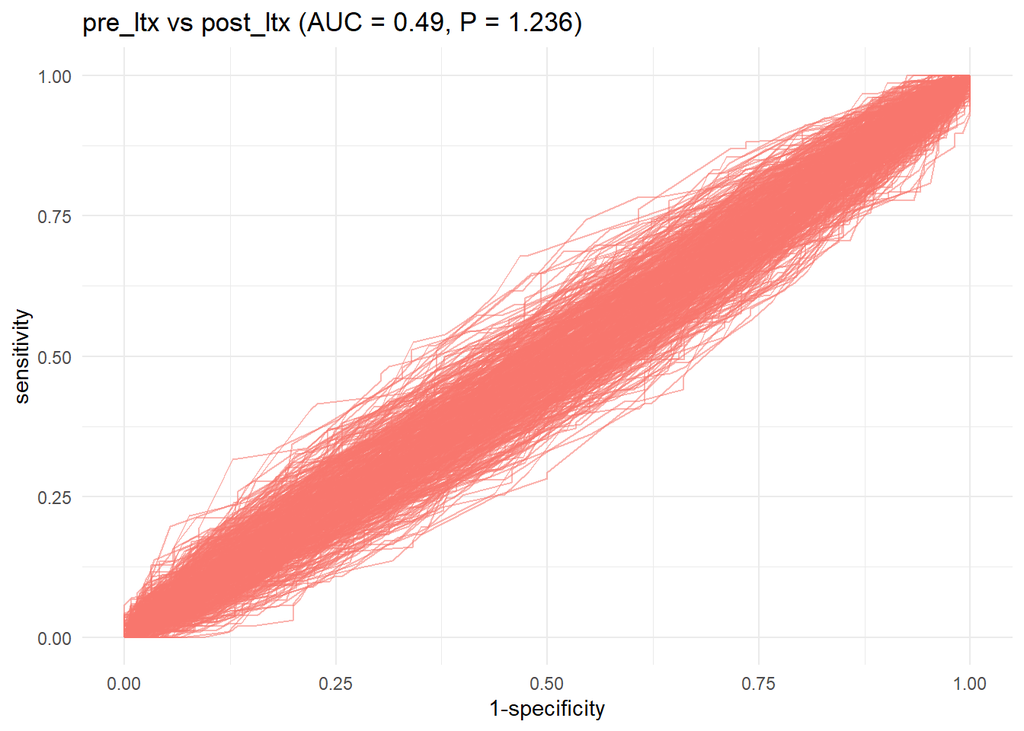

```r
roc_c
```

**post_ltx vs healthy**

```r
group <- c("post_ltx","healthy")
comparison_name <- paste0(group[1], " vs ",group[2])
```

```r
model_name <- paste(comparison_name,level,segment)

# prepare the data
filt_colon_uni_data <- binomial_prep(colon_genus_tab,
                                     colon_genus_taxa_tab,
                                     colon_metadata,
                                     group,
                                     usage="ml_clr",
                                     patient = TRUE)
```

```
Removing 71 ASV(s)
```

```
Removing 5 ASV(s)
```

```r
# fit the model
knn_model <- knn_binomial(filt_colon_uni_data,
                              sample_method = "atypboot",
                              outcome="Group",
                              N=500,
                          clust_var="Patient",
                              reuse=TRUE,
                              file=model_name,
                              Q="Q1",
                          overfitting_check = TRUE)

# ROC curve
roc_c <- roc_curve(knn_model, group)

# save the results
supplements_models[["models_summ"]][["knn_model"]][[model_name]] <- knn_model$model_summary
supplements_models[["roc_cs"]][["knn_model"]][[model_name]] <- knn_model$kfold_rocobjs


# see the results
knn_model$model_summary %>% t()
```

```
                                      [,1]
k                               30.0000000
auc                              0.5929636
auc_optimism_corrected           0.4840235
auc_optimism_corrected_CIL       0.3986432
auc_optimism_corrected_CIU       0.5643297
accuracy                         0.6829746
accuracy_optimism_corrected      0.6282546
accuracy_optimism_corrected_CIL  0.5403005
accuracy_optimism_corrected_CIU  0.6962623
```

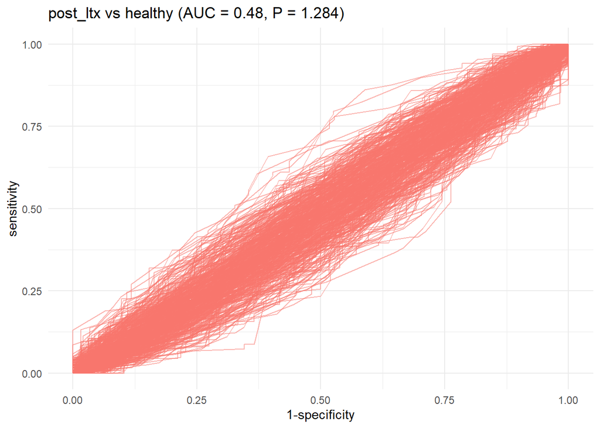

```r
roc_c
```

##### 5.1.2.1.2 RF

```r
model="rf"
```

###### 5.1.2.1.2.1 Genus level

```r
level="genus"
```

Aggregate taxa

```r
genus_data <- aggregate_taxa(colon_asv_tab,
                             colon_taxa_tab,
                             taxonomic_level = level)

colon_genus_tab <- genus_data[[1]]
colon_genus_taxa_tab <- genus_data[[2]]
```

**pre_ltx vs healthy**

```r
group <- c("pre_ltx","healthy")
comparison_name <- paste0(group[1], " vs ",group[2])
```

```r
model_name <- paste(comparison_name,level,segment)

# prepare the data
filt_colon_uni_data <- binomial_prep(colon_genus_tab,
                                     colon_genus_taxa_tab,
                                     colon_metadata,
                                     group,
                                     usage="ml_clr",
                                     patient = TRUE)
```

```
Removing 135 ASV(s)
```

```
Removing 10 ASV(s)
```

```r
# fit the model
rf_model <- rf_binomial(filt_colon_uni_data,
                              sample_method = "atypboot",
                              outcome="Group",
                              N=500,
                        clust_var="Patient",
                              reuse=TRUE,
                              file=model_name,
                              Q="Q1",
                        overfitting_check = TRUE)

# ROC curve
roc_c <- roc_curve(rf_model, group)

# save the results
supplements_models[["models_summ"]][["rf_model"]][[model_name]] <- rf_model$model_summary
supplements_models[["roc_cs"]][["rf_model"]][[model_name]] <- rf_model$kfold_rocobjs

# see the results
rf_model$model_summary %>% t()
```

```
                                [,1]
mtry                            "171"
splitrule                       "gini"
min.node.size                   "5"
auc                             "1"
auc_optimism_corrected          "0.5431729"
auc_optimism_corrected_CIL      "0.4415343"
auc_optimism_corrected_CIU      "0.5874833"
accuracy                        "1"
accuracy_optimism_corrected     "0.5147448"
accuracy_optimism_corrected_CIL "0.4917254"
accuracy_optimism_corrected_CIU "0.5364672"
```

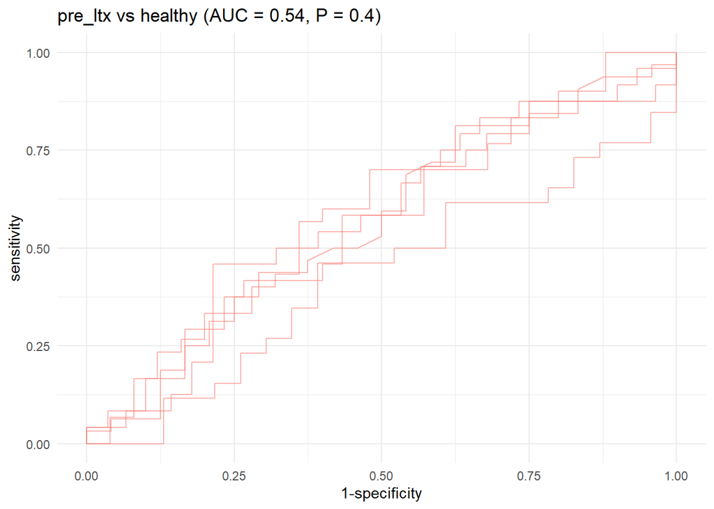

```r
roc_c
```

**pre_ltx vs post_ltx**

```r
group <- c("pre_ltx","post_ltx")
comparison_name <- paste0(group[1], " vs ",group[2])
```

```r
model_name <- paste(comparison_name,level,segment)

# prepare the data
filt_colon_uni_data <- binomial_prep(colon_genus_tab,
                                     colon_genus_taxa_tab,
                                     colon_metadata,
                                     group,
                                     usage="ml_clr",
                                     patient = TRUE)
```

```
Removing 17 ASV(s)
```

```
Removing 10 ASV(s)
```

```r
# fit the model
rf_model <- rf_binomial(filt_colon_uni_data,
                              sample_method = "atypboot",
                              outcome="Group",
                              N=500,
                        clust_var="Patient",
                              reuse=TRUE,
                              file=model_name,
                              Q="Q1",
                        overfitting_check = TRUE)

# ROC curve
roc_c <- roc_curve(rf_model, group)

# save the results
supplements_models[["models_summ"]][["rf_model"]][[model_name]] <- rf_model$model_summary
supplements_models[["roc_cs"]][["rf_model"]][[model_name]] <- rf_model$kfold_rocobjs

# see the results
rf_model$model_summary %>% t()
```

```
                                [,1]
mtry                            "43"
splitrule                       "gini"
min.node.size                   "2"
auc                             "1"
auc_optimism_corrected          "0.5455831"
auc_optimism_corrected_CIL      "0.4784397"
auc_optimism_corrected_CIU      "0.6023098"
accuracy                        "1"
accuracy_optimism_corrected     "0.5610166"
accuracy_optimism_corrected_CIL "0.502336"
accuracy_optimism_corrected_CIU "0.6167833"
```

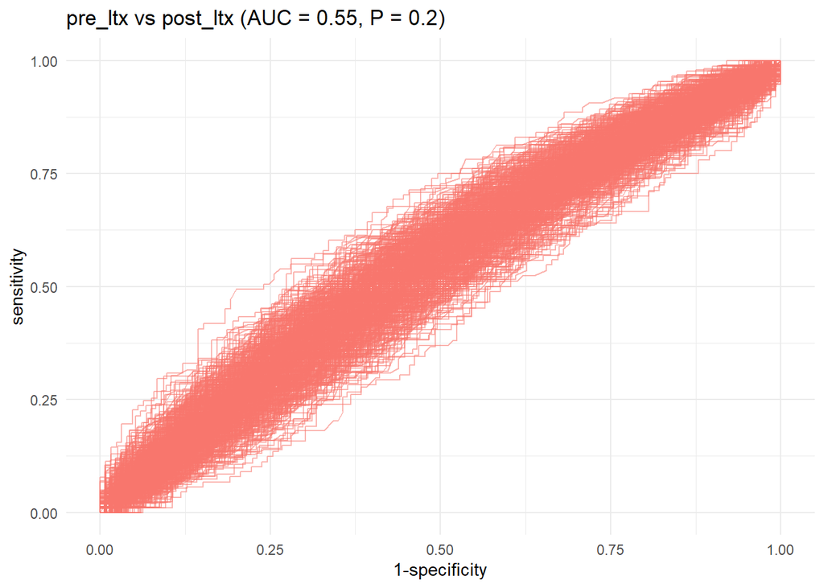

```r
roc_c
```

**post_ltx vs healthy**

```r
group <- c("post_ltx","healthy")
comparison_name <- paste0(group[1], " vs ",group[2])
```

```r
model_name <- paste(comparison_name,level,segment)

# prepare the data
filt_colon_uni_data <- binomial_prep(colon_genus_tab,
                                     colon_genus_taxa_tab,
                                     colon_metadata,
                                     group,
                                     usage="ml_clr",
                                     patient = TRUE)
```

```
Removing 71 ASV(s)
```

```
Removing 5 ASV(s)
```

```r
# fit the model
rf_model <- rf_binomial(filt_colon_uni_data,
                              sample_method = "atypboot",
                              outcome="Group",
                              N=500,
                        clust_var="Patient",
                              reuse=TRUE,
                              file=model_name,
                              Q="Q1",
                        overfitting_check = TRUE)

# ROC curve
roc_c <- roc_curve(rf_model, group)

# save the results
supplements_models[["models_summ"]][["rf_model"]][[model_name]] <- rf_model$model_summary
supplements_models[["roc_cs"]][["rf_model"]][[model_name]] <- rf_model$kfold_rocobjs

# see the results
rf_model$model_summary %>% t()
```

```
                                [,1]
mtry                            "1"
splitrule                       "gini"
min.node.size                   "2"
auc                             "1"
auc_optimism_corrected          "0.4941543"
auc_optimism_corrected_CIL      "0.4149008"
auc_optimism_corrected_CIU      "0.5638735"
accuracy                        "1"
accuracy_optimism_corrected     "0.6589997"
accuracy_optimism_corrected_CIL "0.6017515"
accuracy_optimism_corrected_CIU "0.7087798"
```

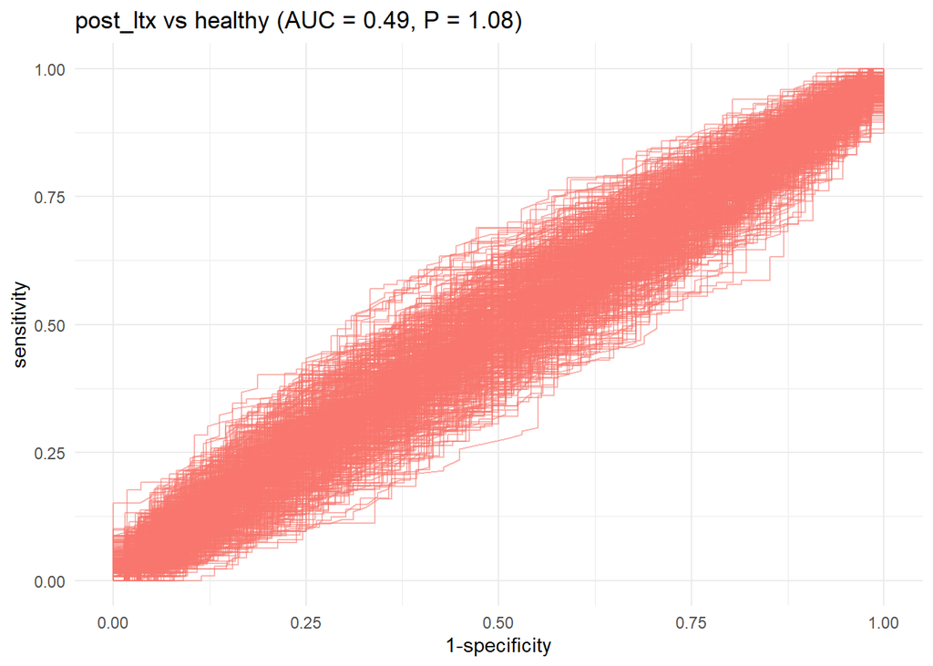

```r
roc_c
```

##### 5.1.2.1.3 GBoost

```r
model="gb"
```

###### 5.1.2.1.3.1 Genus level

```r
level="genus"
```

Aggregate taxa

```r
genus_data <- aggregate_taxa(colon_asv_tab,
                             colon_taxa_tab,
                             taxonomic_level = level)

colon_genus_tab <- genus_data[[1]]
colon_genus_taxa_tab <- genus_data[[2]]
```

**pre_ltx vs healthy**

```r
group <- c("pre_ltx","healthy")
comparison_name <- paste0(group[1], " vs ",group[2])
```

```r
model_name <- paste(comparison_name,level,segment)

# prepare the data
filt_colon_uni_data <- binomial_prep(colon_genus_tab,
                                     colon_genus_taxa_tab,
                                     colon_metadata,
                                     group,
                                     usage="ml_clr",
                                     patient = TRUE)
```

```
Removing 135 ASV(s)
```

```
Removing 10 ASV(s)
```

```r
# fit the model
gbm_model <- gbm_binomial(filt_colon_uni_data,
                              sample_method = "atypboot",
                              outcome="Group",
                              N=500,
                          clust_var="Patient",
                              reuse=TRUE,
                              file=model_name,
                              Q="Q1",
                          overfitting_check = TRUE)

# ROC curve
roc_c <- roc_curve(gbm_model, group)

# save the results
supplements_models[["models_summ"]][["gbm_model"]][[model_name]] <- gbm_model$model_summary
supplements_models[["roc_cs"]][["gbm_model"]][[model_name]] <- gbm_model$kfold_rocobjs

# see the results
gbm_model$model_summary %>% t()
```

```
                                       [,1]
n.trees                         100.0000000
interaction.depth                 1.0000000
shrinkage                         0.1000000
n.minobsinnode                   10.0000000
auc                               0.8847329
auc_optimism_corrected            0.5070577
auc_optimism_corrected_CIL        0.4250892
auc_optimism_corrected_CIU        0.5821484
accuracy                          0.7639903
accuracy_optimism_corrected       0.5066920
accuracy_optimism_corrected_CIL   0.4313082
accuracy_optimism_corrected_CIU   0.5769537
```

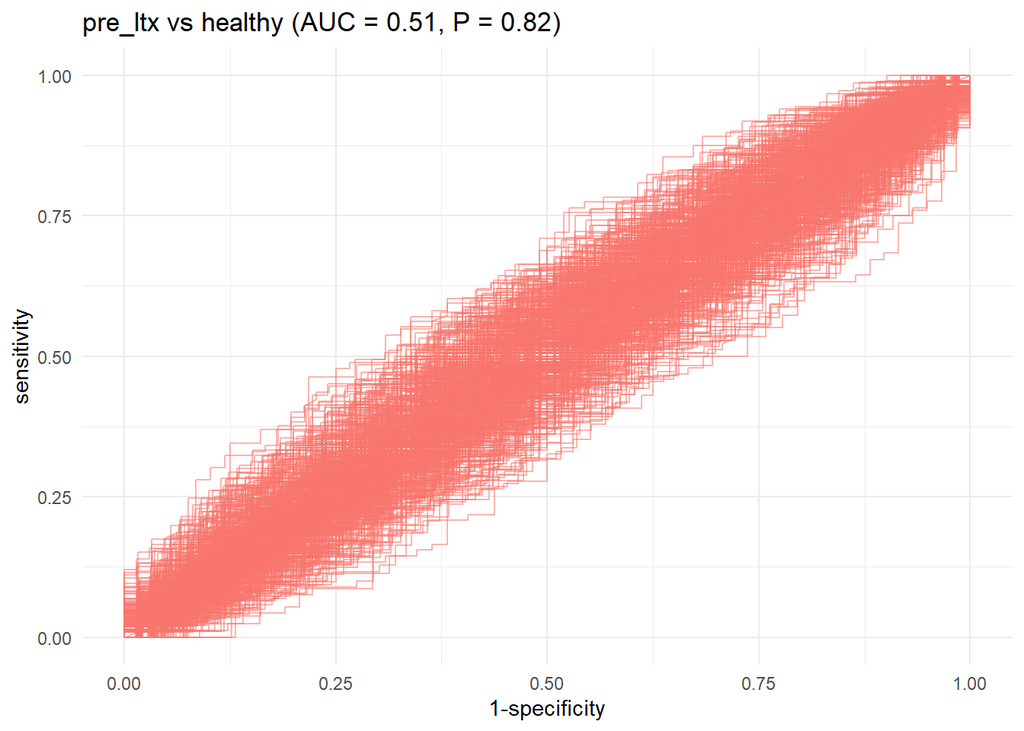

```r
roc_c
```

**pre_ltx vs post_ltx**

```r
group <- c("pre_ltx","post_ltx")
comparison_name <- paste0(group[1], " vs ",group[2])
```

```r
model_name <- paste(comparison_name,level,segment)

# prepare the data
filt_colon_uni_data <- binomial_prep(colon_genus_tab,
                                     colon_genus_taxa_tab,
                                     colon_metadata,
                                     group,
                                     usage="ml_clr",
                                     patient = TRUE)
```

```
Removing 17 ASV(s)
```

```
Removing 10 ASV(s)
```

```r
# fit the model
gbm_model <- gbm_binomial(filt_colon_uni_data,
                              sample_method = "atypboot",
                              outcome="Group",
                              N=500,
                          clust_var="Patient",
                              reuse=TRUE,
                              file=model_name,
                              Q="Q1",
                          overfitting_check = TRUE)

# ROC curve
roc_c <- roc_curve(gbm_model, group)

# save the results
supplements_models[["models_summ"]][["gbm_model"]][[model_name]] <- gbm_model$model_summary
supplements_models[["roc_cs"]][["gbm_model"]][[model_name]] <- gbm_model$kfold_rocobjs

# see the results
gbm_model$model_summary %>% t()
```

```
                                       [,1]
n.trees                         100.0000000
interaction.depth                 3.0000000
shrinkage                         0.1000000
n.minobsinnode                   10.0000000
auc                               0.9571657
auc_optimism_corrected            0.4865905
auc_optimism_corrected_CIL        0.4188913
auc_optimism_corrected_CIU        0.5515051
accuracy                          0.8816667
accuracy_optimism_corrected       0.5557342
accuracy_optimism_corrected_CIL   0.5023909
accuracy_optimism_corrected_CIU   0.6059283
```

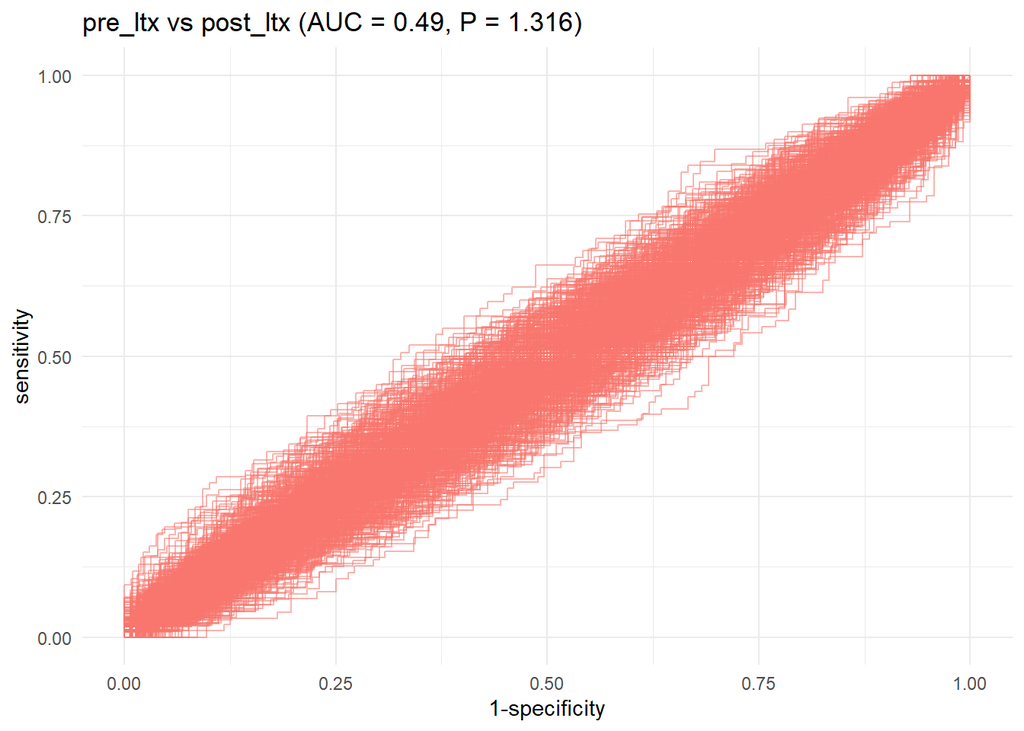

```r
roc_c
```

**post_ltx vs healthy**

```r
group <- c("post_ltx","healthy")
comparison_name <- paste0(group[1], " vs ",group[2])
```

```r
model_name <- paste(comparison_name,level,segment)

# prepare the data
filt_colon_uni_data <- binomial_prep(colon_genus_tab,
                                     colon_genus_taxa_tab,
                                     colon_metadata,
                                     group,
                                     usage="ml_clr",
                                     patient = TRUE)
```

```
Removing 71 ASV(s)
```

```
Removing 5 ASV(s)
```

```r
# fit the model
gbm_model <- gbm_binomial(filt_colon_uni_data,
                              sample_method = "atypboot",
                              outcome="Group",
                              N=500,
                          clust_var="Patient",
                              reuse=TRUE,
                              file=model_name,
                              Q="Q1",
                          overfitting_check = TRUE)

# ROC curve
roc_c <- roc_curve(gbm_model, group)

# save the results
supplements_models[["models_summ"]][["gbm_model"]][[model_name]] <- gbm_model$model_summary
supplements_models[["roc_cs"]][["gbm_model"]][[model_name]] <- gbm_model$kfold_rocobjs

# see the results
gbm_model$model_summary %>% t()
```

```
                                       [,1]
n.trees                         100.0000000
interaction.depth                 1.0000000
shrinkage                         0.1000000
n.minobsinnode                   20.0000000
auc                               0.8581012
auc_optimism_corrected            0.4927075
auc_optimism_corrected_CIL        0.4162465
auc_optimism_corrected_CIU        0.5710246
accuracy                          0.7592955
accuracy_optimism_corrected       0.5687969
accuracy_optimism_corrected_CIL   0.4943182
accuracy_optimism_corrected_CIU   0.6405416
```

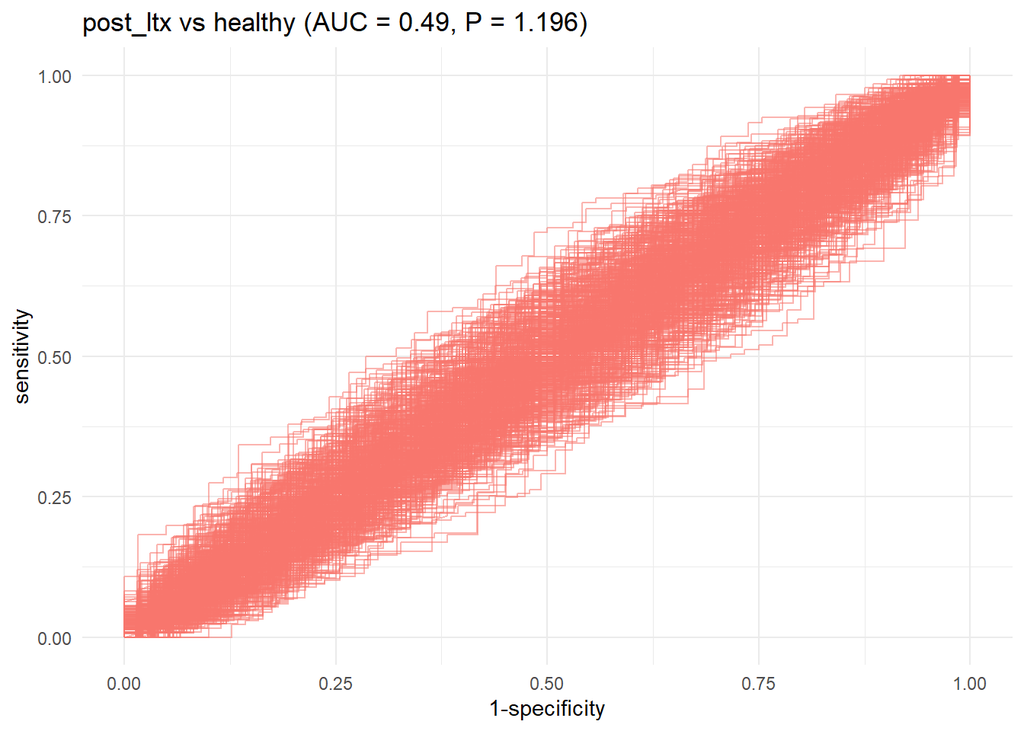

```r
roc_c
```

#### 5.1.2.2 Saving results

```r
models_list <- list()

for (model_name in names(supplements_models$models_summ)){
  df <- do.call(rbind, supplements_models$models_summ[[model_name]])
  models_list[[model_name]] <- df
}

write.xlsx(models_list,
           file=file.path(path,paste0("supplements_models_",segment,".xlsx")),
           rowNames=TRUE)
```

# 6 Overview

```r
models_summ_df <- do.call(rbind,
  models_summ)
```

```r
# Build final dataframe
models_list[["enet_model"]] <- models_summ_df
final_df <- tibble(row_names = rownames(models_list[[1]]))

# Loop through models and extract required values
for (model_name in names(models_list)) {
  model_df <- models_list[[model_name]]

  # Combine AUC_optimism_corrected with its CI values
  final_df[[model_name]] <- paste0(
    round(model_df$auc_optimism_corrected, 3),
    " (", round(model_df$auc_optimism_corrected_CIL, 3), "; ",
    round(model_df$auc_optimism_corrected_CIU, 3), ")"
  )
}

# see the results
knitr::kable(final_df, caption="All models")
```

All models

| row_names | knn_model | rf_model | gbm_model | enet_model |
| --- | --- | --- | --- | --- |
| pre_ltx vs healthy genus terminal_ileum | 0.511 (0.361; 0.662) | 0.437 (0.298; 0.575) | 0.432 (0.294; 0.538) | 0.448 (0.324; 0.595) |
| pre_ltx vs post_ltx genus terminal_ileum | 0.469 (0.355; 0.593) | 0.417 (0.312; 0.517) | 0.501 (0.384; 0.622) | 0.444 (0.326; 0.561) |
| post_ltx vs healthy genus terminal_ileum | 0.479 (0.354; 0.597) | 0.476 (0.368; 0.595) | 0.573 (0.458; 0.689) | 0.518 (0.393; 0.622) |
| pre_ltx vs healthy genus colon | 0.494 (0.397; 0.586) | 0.543 (0.442; 0.587) | 0.507 (0.425; 0.582) | 0.5 (0.42; 0.582) |
| pre_ltx vs post_ltx genus colon | 0.489 (0.423; 0.557) | 0.546 (0.478; 0.602) | 0.487 (0.419; 0.552) | 0.499 (0.439; 0.558) |
| post_ltx vs healthy genus colon | 0.484 (0.399; 0.564) | 0.494 (0.415; 0.564) | 0.493 (0.416; 0.571) | 0.492 (0.415; 0.569) |